# Exercise 5: Univariate Optimization

[Optimization in Machine Learning](https://slds-lmu.github.io/website_optimization/)

**Reproducibility**

Produced with Python 3.10 and R 4.4.1. To reproduce, install the pinned package versions below.

**Python**

```bash
pip install numpy==2.0.2 matplotlib==3.10.8
```

**R**

```r
install.packages("remotes")
remotes::install_version("ggplot2", "3.5.1")
```

## Setup

You are given the following data situation:

**R**

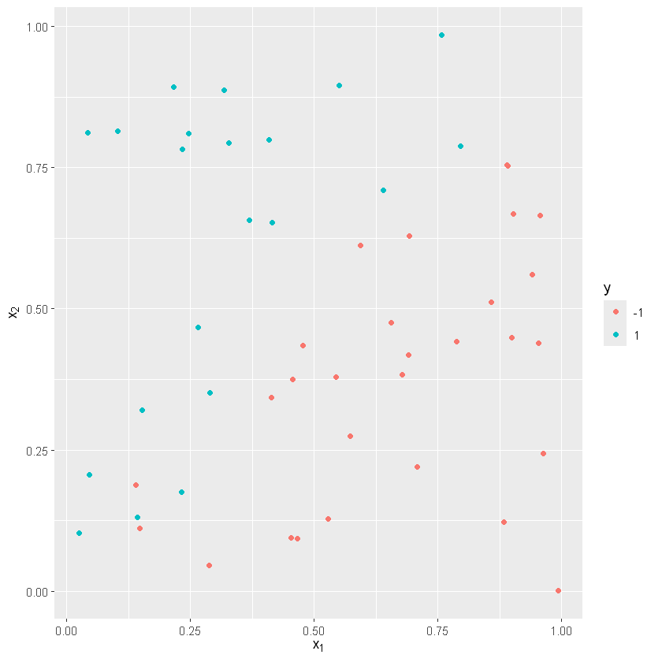

```r
library(ggplot2)

set.seed(123)

X <- matrix(runif(100), ncol = 2)
y <- -((X %*% c(-1, 1) + rnorm(50, 0, 0.1) < 0) * 2 - 1)
df <- as.data.frame(X)
df$type <- as.character(y)

ggplot(df) +
  geom_point(aes(x = V1, y = V2, color = type)) +
  xlab(expression(x[1])) +
  ylab(expression(x[2])) +
  labs(color = "y")
```

**Python**

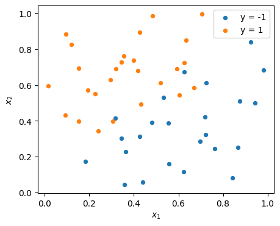

```python
import numpy as np
import matplotlib.pyplot as plt

np.random.seed(123)

X = np.random.uniform(size=(50, 2))
lin = X @ np.array([-1.0, 1.0]) + np.random.normal(0, 0.1, 50)
y = -((lin < 0).astype(int) * 2 - 1)

fig, ax = plt.subplots(figsize=(5, 4))
for label in (-1, 1):
    mask = y == label
    ax.scatter(X[mask, 0], X[mask, 1], label=f"y = {label}", s=18)
ax.set_xlabel(r"$x_1$")
ax.set_ylabel(r"$x_2$")
ax.legend()
plt.show()
```

**Note**

**R vs. Python parity.** R’s `set.seed(123)` and Python’s `np.random.seed(123)` use *different* RNGs. The data above (and consequently the optima below) differ between languages. Both implementations are correct; only the underlying data differs. When comparing R and Python, look at *algorithmic behavior* (convergence, bracket shrinking, zig-zag pattern) rather than expecting numerically identical $\boldsymbol{\theta}$ values.

In the following we want to estimate a linear SVM without intercept and with $\lambda = 1$. We assume we know that $\boldsymbol{\theta}_2 = 2$.

## (a) Convexity of a 1D slice

Show that if $f:\mathbb{R}^2 \to \mathbb{R}$ is convex then $g_c: \mathbb{R}\to \mathbb{R}, \ x \mapsto f(x, c)$ for any $c\in\mathbb{R}$ is convex.

## (b) Why the non-geometric primal SVM

Explain why the non-geometric primal linear SVM formulation should be used rather than the geometric one if we want to find $\boldsymbol{\theta}_1$ via the golden-ratio algorithm.

*Note: We use this algorithm for educational purposes; in practice more advanced algorithms are typically used.*

## (c) Golden-section search

Find $\boldsymbol{\theta}_1$ via the golden-section algorithm. Implement the algorithm yourself. Use absolute error $0.01$ as termination criterion and $[-3, 3]$ as the starting interval.

## (d) Parabola interpolation through three points

Given three points $(x_1, y_1), (x_2, y_2), (x_3, y_3)$ show that the parameters $a, b, c \in \mathbb{R}$ of the interpolating parabola $p(x) = ax^2 + bx + c$ can be found via

$$\begin{pmatrix}a \\ b \\ c \end{pmatrix} = \begin{pmatrix} x_1^2 & x_1 & 1 \\ x_2^2 & x_2 & 1 \\ x_3^2 & x_3 & 1 \end{pmatrix}^{-1} \begin{pmatrix}y_1 \\ y_2 \\ y_3 \end{pmatrix}.$$

## (e) Brent’s method

Find $\boldsymbol{\theta}_1$ via Brent’s method. Implement a simplified version (only check whether the proposed point is in the current interval) of the algorithm. Use absolute error $0.01$ as termination criterion and $[-3, 3]$ as the starting interval. For the first step, use a golden-ratio step.

## (f) Alternating univariate minimization

Now assume we do not know $\boldsymbol{\theta}_2$. Initial guess is $\boldsymbol{\theta}_2 = 0$. Alternately minimize w.r.t. either $\boldsymbol{\theta}_1$ or $\boldsymbol{\theta}_2$ via the golden-section method (starting interval reset to $[-3, 3]$ each time) while holding the other parameter fixed. Switch to the other parameter when absolute error is smaller than $0.01$. Repeat this procedure $10$ times.

## (g) Optimization trace

How does the optimization trace of (f) look in parameter space?